# Risk Factor Analysis

## Outcome Variable

**Outcome Variable:** ever_stunted

## Predictor Variables

**Intervention Variable:** tr

**Adjustment Set:**

unadjusted

## Stratifying Variables

The analysis was stratified on these variable(s):

- anywast06
- agecat
- studyid
- country

## Data Summary

| anywast06 | agecat | studyid | country | tr | ever_stunted | n_cell | n |
| --- | --- | --- | --- | --- | --- | --- | --- |
| 0 | 0-6 months | ki1017093b-PROVIDE | BANGLADESH | Control | 0 | 106 | 474 |
| 0 | 0-6 months | ki1017093b-PROVIDE | BANGLADESH | Control | 1 | 14 | 474 |
| 0 | 0-6 months | ki1017093b-PROVIDE | BANGLADESH | Other | 0 | 308 | 474 |
| 0 | 0-6 months | ki1017093b-PROVIDE | BANGLADESH | Other | 1 | 46 | 474 |
| 1 | 0-6 months | ki1017093b-PROVIDE | BANGLADESH | Control | 0 | 36 | 166 |
| 1 | 0-6 months | ki1017093b-PROVIDE | BANGLADESH | Control | 1 | 10 | 166 |
| 1 | 0-6 months | ki1017093b-PROVIDE | BANGLADESH | Other | 0 | 101 | 166 |
| 1 | 0-6 months | ki1017093b-PROVIDE | BANGLADESH | Other | 1 | 19 | 166 |
| 1 | 0-6 months | ki1066203-TanzaniaChild2 | TANZANIA, UNITED REPUBLIC OF | Control | 0 | 64 | 329 |
| 1 | 0-6 months | ki1066203-TanzaniaChild2 | TANZANIA, UNITED REPUBLIC OF | Control | 1 | 3 | 329 |
| 1 | 0-6 months | ki1066203-TanzaniaChild2 | TANZANIA, UNITED REPUBLIC OF | Other | 0 | 87 | 329 |
| 1 | 0-6 months | ki1066203-TanzaniaChild2 | TANZANIA, UNITED REPUBLIC OF | Other | 1 | 5 | 329 |
| 1 | 0-6 months | ki1066203-TanzaniaChild2 | TANZANIA, UNITED REPUBLIC OF | Zinc | 0 | 150 | 329 |
| 1 | 0-6 months | ki1066203-TanzaniaChild2 | TANZANIA, UNITED REPUBLIC OF | Zinc | 1 | 20 | 329 |
| 0 | 0-6 months | ki1066203-TanzaniaChild2 | TANZANIA, UNITED REPUBLIC OF | Control | 0 | 453 | 1905 |
| 0 | 0-6 months | ki1066203-TanzaniaChild2 | TANZANIA, UNITED REPUBLIC OF | Control | 1 | 37 | 1905 |
| 0 | 0-6 months | ki1066203-TanzaniaChild2 | TANZANIA, UNITED REPUBLIC OF | Other | 0 | 432 | 1905 |
| 0 | 0-6 months | ki1066203-TanzaniaChild2 | TANZANIA, UNITED REPUBLIC OF | Other | 1 | 31 | 1905 |
| 0 | 0-6 months | ki1066203-TanzaniaChild2 | TANZANIA, UNITED REPUBLIC OF | Zinc | 0 | 889 | 1905 |
| 0 | 0-6 months | ki1066203-TanzaniaChild2 | TANZANIA, UNITED REPUBLIC OF | Zinc | 1 | 63 | 1905 |
| 0 | 0-6 months | ki1112895-Guatemala BSC | GUATEMALA | Control | 0 | 90 | 235 |
| 0 | 0-6 months | ki1112895-Guatemala BSC | GUATEMALA | Control | 1 | 28 | 235 |
| 0 | 0-6 months | ki1112895-Guatemala BSC | GUATEMALA | Other | 0 | 93 | 235 |
| 0 | 0-6 months | ki1112895-Guatemala BSC | GUATEMALA | Other | 1 | 24 | 235 |
| 1 | 0-6 months | ki1112895-Guatemala BSC | GUATEMALA | Control | 0 | 0 | 6 |
| 1 | 0-6 months | ki1112895-Guatemala BSC | GUATEMALA | Control | 1 | 2 | 6 |
| 1 | 0-6 months | ki1112895-Guatemala BSC | GUATEMALA | Other | 0 | 3 | 6 |
| 1 | 0-6 months | ki1112895-Guatemala BSC | GUATEMALA | Other | 1 | 1 | 6 |
| 0 | 6-24 months | ki1017093b-PROVIDE | BANGLADESH | Control | 0 | 80 | 374 |
| 0 | 6-24 months | ki1017093b-PROVIDE | BANGLADESH | Control | 1 | 18 | 374 |

[output cut: 52 more lines]

The following strata were considered:

- anywast06: 0, agecat: 0-24 months, studyid: ki1017093b-PROVIDE, country: BANGLADESH
- anywast06: 0, agecat: 0-24 months, studyid: ki1066203-TanzaniaChild2, country: TANZANIA, UNITED REPUBLIC OF
- anywast06: 0, agecat: 0-24 months, studyid: ki1112895-Guatemala BSC, country: GUATEMALA
- anywast06: 0, agecat: 0-6 months, studyid: ki1017093b-PROVIDE, country: BANGLADESH
- anywast06: 0, agecat: 0-6 months, studyid: ki1066203-TanzaniaChild2, country: TANZANIA, UNITED REPUBLIC OF
- anywast06: 0, agecat: 0-6 months, studyid: ki1112895-Guatemala BSC, country: GUATEMALA
- anywast06: 0, agecat: 6-24 months, studyid: ki1017093b-PROVIDE, country: BANGLADESH
- anywast06: 0, agecat: 6-24 months, studyid: ki1066203-TanzaniaChild2, country: TANZANIA, UNITED REPUBLIC OF
- anywast06: 0, agecat: 6-24 months, studyid: ki1112895-Guatemala BSC, country: GUATEMALA
- anywast06: 1, agecat: 0-24 months, studyid: ki1017093b-PROVIDE, country: BANGLADESH
- anywast06: 1, agecat: 0-24 months, studyid: ki1066203-TanzaniaChild2, country: TANZANIA, UNITED REPUBLIC OF
- anywast06: 1, agecat: 0-24 months, studyid: ki1112895-Guatemala BSC, country: GUATEMALA
- anywast06: 1, agecat: 0-6 months, studyid: ki1017093b-PROVIDE, country: BANGLADESH
- anywast06: 1, agecat: 0-6 months, studyid: ki1066203-TanzaniaChild2, country: TANZANIA, UNITED REPUBLIC OF
- anywast06: 1, agecat: 0-6 months, studyid: ki1112895-Guatemala BSC, country: GUATEMALA
- anywast06: 1, agecat: 6-24 months, studyid: ki1017093b-PROVIDE, country: BANGLADESH
- anywast06: 1, agecat: 6-24 months, studyid: ki1066203-TanzaniaChild2, country: TANZANIA, UNITED REPUBLIC OF
- anywast06: 1, agecat: 6-24 months, studyid: ki1112895-Guatemala BSC, country: GUATEMALA

### Dropped Strata

Some strata were dropped due to rare outcomes:

- anywast06: 1, agecat: 0-6 months, studyid: ki1066203-TanzaniaChild2, country: TANZANIA, UNITED REPUBLIC OF
- anywast06: 1, agecat: 0-6 months, studyid: ki1112895-Guatemala BSC, country: GUATEMALA
- anywast06: 1, agecat: 6-24 months, studyid: ki1112895-Guatemala BSC, country: GUATEMALA
- anywast06: 1, agecat: 0-24 months, studyid: ki1112895-Guatemala BSC, country: GUATEMALA

## Methods Detail

We’re interested in the causal parameters $E[Y_a]$ for all values of $a \in \mathcal{A}$. These parameters represent the mean outcome if, possibly contrary to fact, we intervened to set all units to have $A=a$. Under the randomization and positivity assumptions, these are identified by the statistical parameters $\psi_a=E_W[E_{Y|A,W}(Y|A=a,W)]$. In addition, we’re interested in the mean of $Y$, $E[Y]$ under no intervention (the observed mean). We will estimate these parameters by using SuperLearner to fit the relevant likelihood factors – $E_{Y|A,W}(Y|A=a,W)$ and $p(A=a|W)$, and then updating our likelihood fit using a joint TMLE.

For unadjusted analyses ($W=\{\}$), initial likelihoods were estimated using Lrnr_glm to estimate the simple $E(Y|A)$ and Lrnr_mean to estimate $p(A)$. For adjusted analyses, a small library containing Lrnr_glmnet, Lrnr_xgboost, and Lrnr_mean was used.

Having estimated these parameters, we will then use the delta method to estimate relative risks and attributable risks relative to a prespecified baseline level of $A$.

# Results Detail

## Results Plots

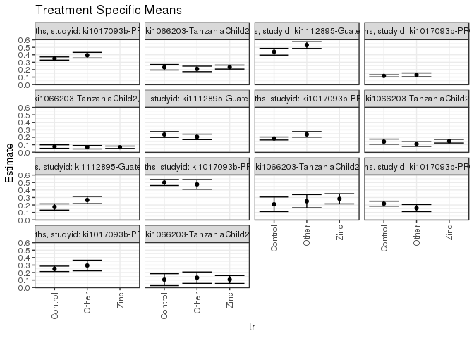

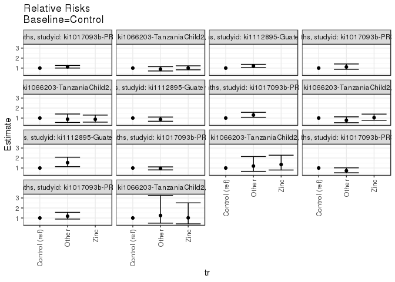

[figure not shown]

[figure not shown]

## Results Table

### Parameter: TSM

| anywast06 | agecat | studyid | country | intervention_level | baseline_level | estimate | ci_lower | ci_upper |
| --- | --- | --- | --- | --- | --- | --- | --- | --- |
| 0 | 0-24 months | ki1017093b-PROVIDE | BANGLADESH | Control | NA | 0.3500000 | 0.3284179 | 0.3715821 |
| 0 | 0-24 months | ki1017093b-PROVIDE | BANGLADESH | Other | NA | 0.3943662 | 0.3563314 | 0.4324010 |
| 0 | 0-24 months | ki1066203-TanzaniaChild2 | TANZANIA, UNITED REPUBLIC OF | Control | NA | 0.2323232 | 0.1951103 | 0.2695362 |
| 0 | 0-24 months | ki1066203-TanzaniaChild2 | TANZANIA, UNITED REPUBLIC OF | Other | NA | 0.2098501 | 0.1729088 | 0.2467914 |
| 0 | 0-24 months | ki1066203-TanzaniaChild2 | TANZANIA, UNITED REPUBLIC OF | Zinc | NA | 0.2344398 | 0.2076896 | 0.2611901 |
| 0 | 0-24 months | ki1112895-Guatemala BSC | GUATEMALA | Control | NA | 0.4406780 | 0.3956026 | 0.4857533 |
| 0 | 0-24 months | ki1112895-Guatemala BSC | GUATEMALA | Other | NA | 0.5299145 | 0.4847923 | 0.5750368 |
| 0 | 0-6 months | ki1017093b-PROVIDE | BANGLADESH | Control | NA | 0.1166667 | 0.1021102 | 0.1312231 |
| 0 | 0-6 months | ki1017093b-PROVIDE | BANGLADESH | Other | NA | 0.1299435 | 0.1037568 | 0.1561302 |
| 0 | 0-6 months | ki1066203-TanzaniaChild2 | TANZANIA, UNITED REPUBLIC OF | Control | NA | 0.0755102 | 0.0521101 | 0.0989103 |
| 0 | 0-6 months | ki1066203-TanzaniaChild2 | TANZANIA, UNITED REPUBLIC OF | Other | NA | 0.0669546 | 0.0441820 | 0.0897273 |
| 0 | 0-6 months | ki1066203-TanzaniaChild2 | TANZANIA, UNITED REPUBLIC OF | Zinc | NA | 0.0661765 | 0.0503812 | 0.0819718 |
| 0 | 0-6 months | ki1112895-Guatemala BSC | GUATEMALA | Control | NA | 0.2372881 | 0.1986634 | 0.2759129 |
| 0 | 0-6 months | ki1112895-Guatemala BSC | GUATEMALA | Other | NA | 0.2051282 | 0.1686225 | 0.2416339 |
| 0 | 6-24 months | ki1017093b-PROVIDE | BANGLADESH | Control | NA | 0.1836735 | 0.1635582 | 0.2037887 |
| 0 | 6-24 months | ki1017093b-PROVIDE | BANGLADESH | Other | NA | 0.2391304 | 0.2019440 | 0.2763169 |
| 0 | 6-24 months | ki1066203-TanzaniaChild2 | TANZANIA, UNITED REPUBLIC OF | Control | NA | 0.1418093 | 0.1079897 | 0.1756288 |
| 0 | 6-24 months | ki1066203-TanzaniaChild2 | TANZANIA, UNITED REPUBLIC OF | Other | NA | 0.1096606 | 0.0783574 | 0.1409638 |
| 0 | 6-24 months | ki1066203-TanzaniaChild2 | TANZANIA, UNITED REPUBLIC OF | Zinc | NA | 0.1479140 | 0.1231658 | 0.1726622 |
| 0 | 6-24 months | ki1112895-Guatemala BSC | GUATEMALA | Control | NA | 0.1728395 | 0.1310229 | 0.2146561 |
| 0 | 6-24 months | ki1112895-Guatemala BSC | GUATEMALA | Other | NA | 0.2658228 | 0.2175725 | 0.3140730 |
| 1 | 0-24 months | ki1017093b-PROVIDE | BANGLADESH | Control | NA | 0.5000000 | 0.4598393 | 0.5401607 |
| 1 | 0-24 months | ki1017093b-PROVIDE | BANGLADESH | Other | NA | 0.4750000 | 0.4102158 | 0.5397842 |
| 1 | 0-24 months | ki1066203-TanzaniaChild2 | TANZANIA, UNITED REPUBLIC OF | Control | NA | 0.2089552 | 0.1114565 | 0.3064539 |
| 1 | 0-24 months | ki1066203-TanzaniaChild2 | TANZANIA, UNITED REPUBLIC OF | Other | NA | 0.2500000 | 0.1613832 | 0.3386168 |
| 1 | 0-24 months | ki1066203-TanzaniaChild2 | TANZANIA, UNITED REPUBLIC OF | Zinc | NA | 0.2823529 | 0.2145831 | 0.3501228 |
| 1 | 0-6 months | ki1017093b-PROVIDE | BANGLADESH | Control | NA | 0.2173913 | 0.1842611 | 0.2505215 |
| 1 | 0-6 months | ki1017093b-PROVIDE | BANGLADESH | Other | NA | 0.1583333 | 0.1109747 | 0.2056919 |
| 1 | 6-24 months | ki1017093b-PROVIDE | BANGLADESH | Control | NA | 0.2500000 | 0.2133398 | 0.2866602 |
| 1 | 6-24 months | ki1017093b-PROVIDE | BANGLADESH | Other | NA | 0.2947368 | 0.2236367 | 0.3658369 |
| 1 | 6-24 months | ki1066203-TanzaniaChild2 | TANZANIA, UNITED REPUBLIC OF | Control | NA | 0.1052632 | 0.0254415 | 0.1850848 |
| 1 | 6-24 months | ki1066203-TanzaniaChild2 | TANZANIA, UNITED REPUBLIC OF | Other | NA | 0.1315789 | 0.0554370 | 0.2077209 |
| 1 | 6-24 months | ki1066203-TanzaniaChild2 | TANZANIA, UNITED REPUBLIC OF | Zinc | NA | 0.1068702 | 0.0538646 | 0.1598759 |

### Parameter: E(Y)

| anywast06 | agecat | studyid | country | intervention_level | baseline_level | estimate | ci_lower | ci_upper |
| --- | --- | --- | --- | --- | --- | --- | --- | --- |
| 0 | 0-24 months | ki1017093b-PROVIDE | BANGLADESH | NA | NA | 0.3831579 | 0.3393921 | 0.4269237 |
| 0 | 0-24 months | ki1066203-TanzaniaChild2 | TANZANIA, UNITED REPUBLIC OF | NA | NA | 0.2279335 | 0.2091938 | 0.2466733 |
| 0 | 0-24 months | ki1112895-Guatemala BSC | GUATEMALA | NA | NA | 0.4851064 | 0.4210714 | 0.5491414 |
| 0 | 0-6 months | ki1017093b-PROVIDE | BANGLADESH | NA | NA | 0.1265823 | 0.0966172 | 0.1565473 |
| 0 | 0-6 months | ki1066203-TanzaniaChild2 | TANZANIA, UNITED REPUBLIC OF | NA | NA | 0.0687664 | 0.0573998 | 0.0801330 |
| 0 | 0-6 months | ki1112895-Guatemala BSC | GUATEMALA | NA | NA | 0.2212766 | 0.1680903 | 0.2744629 |
| 0 | 6-24 months | ki1017093b-PROVIDE | BANGLADESH | NA | NA | 0.2245989 | 0.1822482 | 0.2669496 |
| 0 | 6-24 months | ki1066203-TanzaniaChild2 | TANZANIA, UNITED REPUBLIC OF | NA | NA | 0.1370815 | 0.1201335 | 0.1540295 |
| 0 | 6-24 months | ki1112895-Guatemala BSC | GUATEMALA | NA | NA | 0.2187500 | 0.1544933 | 0.2830067 |
| 1 | 0-24 months | ki1017093b-PROVIDE | BANGLADESH | NA | NA | 0.4819277 | 0.4056861 | 0.5581694 |
| 1 | 0-24 months | ki1066203-TanzaniaChild2 | TANZANIA, UNITED REPUBLIC OF | NA | NA | 0.2583587 | 0.2109869 | 0.3057304 |
| 1 | 0-6 months | ki1017093b-PROVIDE | BANGLADESH | NA | NA | 0.1746988 | 0.1167616 | 0.2326360 |
| 1 | 6-24 months | ki1017093b-PROVIDE | BANGLADESH | NA | NA | 0.2845528 | 0.2044886 | 0.3646171 |
| 1 | 6-24 months | ki1066203-TanzaniaChild2 | TANZANIA, UNITED REPUBLIC OF | NA | NA | 0.1136364 | 0.0752802 | 0.1519925 |

### Parameter: RR

| anywast06 | agecat | studyid | country | intervention_level | baseline_level | estimate | ci_lower | ci_upper |
| --- | --- | --- | --- | --- | --- | --- | --- | --- |
| 0 | 0-24 months | ki1017093b-PROVIDE | BANGLADESH | Control | Control | 1.0000000 | 1.0000000 | 1.000000 |
| 0 | 0-24 months | ki1017093b-PROVIDE | BANGLADESH | Other | Control | 1.1267606 | 1.0048857 | 1.263417 |
| 0 | 0-24 months | ki1066203-TanzaniaChild2 | TANZANIA, UNITED REPUBLIC OF | Control | Control | 1.0000000 | 1.0000000 | 1.000000 |
| 0 | 0-24 months | ki1066203-TanzaniaChild2 | TANZANIA, UNITED REPUBLIC OF | Other | Control | 0.9032679 | 0.7119557 | 1.145988 |
| 0 | 0-24 months | ki1066203-TanzaniaChild2 | TANZANIA, UNITED REPUBLIC OF | Zinc | Control | 1.0091106 | 0.8289517 | 1.228424 |
| 0 | 0-24 months | ki1112895-Guatemala BSC | GUATEMALA | Control | Control | 1.0000000 | 1.0000000 | 1.000000 |
| 0 | 0-24 months | ki1112895-Guatemala BSC | GUATEMALA | Other | Control | 1.2024984 | 1.0526503 | 1.373678 |
| 0 | 0-6 months | ki1017093b-PROVIDE | BANGLADESH | Control | Control | 1.0000000 | 1.0000000 | 1.000000 |
| 0 | 0-6 months | ki1017093b-PROVIDE | BANGLADESH | Other | Control | 1.1138015 | 0.8787606 | 1.411708 |
| 0 | 0-6 months | ki1066203-TanzaniaChild2 | TANZANIA, UNITED REPUBLIC OF | Control | Control | 1.0000000 | 1.0000000 | 1.000000 |
| 0 | 0-6 months | ki1066203-TanzaniaChild2 | TANZANIA, UNITED REPUBLIC OF | Other | Control | 0.8866966 | 0.5596867 | 1.404770 |
| 0 | 0-6 months | ki1066203-TanzaniaChild2 | TANZANIA, UNITED REPUBLIC OF | Zinc | Control | 0.8763911 | 0.5926802 | 1.295912 |
| 0 | 0-6 months | ki1112895-Guatemala BSC | GUATEMALA | Control | Control | 1.0000000 | 1.0000000 | 1.000000 |
| 0 | 0-6 months | ki1112895-Guatemala BSC | GUATEMALA | Other | Control | 0.8644689 | 0.6792137 | 1.100252 |
| 0 | 6-24 months | ki1017093b-PROVIDE | BANGLADESH | Control | Control | 1.0000000 | 1.0000000 | 1.000000 |
| 0 | 6-24 months | ki1017093b-PROVIDE | BANGLADESH | Other | Control | 1.3019324 | 1.0764288 | 1.574677 |
| 0 | 6-24 months | ki1066203-TanzaniaChild2 | TANZANIA, UNITED REPUBLIC OF | Control | Control | 1.0000000 | 1.0000000 | 1.000000 |
| 0 | 6-24 months | ki1066203-TanzaniaChild2 | TANZANIA, UNITED REPUBLIC OF | Other | Control | 0.7732961 | 0.5330918 | 1.121733 |
| 0 | 6-24 months | ki1066203-TanzaniaChild2 | TANZANIA, UNITED REPUBLIC OF | Zinc | Control | 1.0430490 | 0.7794426 | 1.395807 |
| 0 | 6-24 months | ki1112895-Guatemala BSC | GUATEMALA | Control | Control | 1.0000000 | 1.0000000 | 1.000000 |
| 0 | 6-24 months | ki1112895-Guatemala BSC | GUATEMALA | Other | Control | 1.5379747 | 1.1365617 | 2.081159 |
| 1 | 0-24 months | ki1017093b-PROVIDE | BANGLADESH | Control | Control | 1.0000000 | 1.0000000 | 1.000000 |
| 1 | 0-24 months | ki1017093b-PROVIDE | BANGLADESH | Other | Control | 0.9500000 | 0.8109287 | 1.112921 |
| 1 | 0-24 months | ki1066203-TanzaniaChild2 | TANZANIA, UNITED REPUBLIC OF | Control | Control | 1.0000000 | 1.0000000 | 1.000000 |
| 1 | 0-24 months | ki1066203-TanzaniaChild2 | TANZANIA, UNITED REPUBLIC OF | Other | Control | 1.1964286 | 0.6658897 | 2.149667 |
| 1 | 0-24 months | ki1066203-TanzaniaChild2 | TANZANIA, UNITED REPUBLIC OF | Zinc | Control | 1.3512605 | 0.7995738 | 2.283598 |
| 1 | 0-6 months | ki1017093b-PROVIDE | BANGLADESH | Control | Control | 1.0000000 | 1.0000000 | 1.000000 |
| 1 | 0-6 months | ki1017093b-PROVIDE | BANGLADESH | Other | Control | 0.7283333 | 0.5206431 | 1.018873 |
| 1 | 6-24 months | ki1017093b-PROVIDE | BANGLADESH | Control | Control | 1.0000000 | 1.0000000 | 1.000000 |
| 1 | 6-24 months | ki1017093b-PROVIDE | BANGLADESH | Other | Control | 1.1789474 | 0.8889769 | 1.563502 |
| 1 | 6-24 months | ki1066203-TanzaniaChild2 | TANZANIA, UNITED REPUBLIC OF | Control | Control | 1.0000000 | 1.0000000 | 1.000000 |
| 1 | 6-24 months | ki1066203-TanzaniaChild2 | TANZANIA, UNITED REPUBLIC OF | Other | Control | 1.2500000 | 0.4815519 | 3.244717 |
| 1 | 6-24 months | ki1066203-TanzaniaChild2 | TANZANIA, UNITED REPUBLIC OF | Zinc | Control | 1.0152672 | 0.4102648 | 2.512444 |

### Parameter: PAR

| anywast06 | agecat | studyid | country | intervention_level | baseline_level | estimate | ci_lower | ci_upper |
| --- | --- | --- | --- | --- | --- | --- | --- | --- |
| 0 | 0-24 months | ki1017093b-PROVIDE | BANGLADESH | Control | NA | 0.0331579 | -0.0049165 | 0.0712323 |
| 0 | 0-24 months | ki1066203-TanzaniaChild2 | TANZANIA, UNITED REPUBLIC OF | Control | NA | -0.0043897 | -0.0363923 | 0.0276129 |
| 0 | 0-24 months | ki1112895-Guatemala BSC | GUATEMALA | Control | NA | 0.0444284 | -0.0010545 | 0.0899113 |
| 0 | 0-6 months | ki1017093b-PROVIDE | BANGLADESH | Control | NA | 0.0099156 | -0.0162763 | 0.0361075 |
| 0 | 0-6 months | ki1066203-TanzaniaChild2 | TANZANIA, UNITED REPUBLIC OF | Control | NA | -0.0067438 | -0.0266204 | 0.0131328 |
| 0 | 0-6 months | ki1112895-Guatemala BSC | GUATEMALA | Control | NA | -0.0160115 | -0.0525753 | 0.0205522 |
| 0 | 6-24 months | ki1017093b-PROVIDE | BANGLADESH | Control | NA | 0.0409255 | 0.0036567 | 0.0781942 |
| 0 | 6-24 months | ki1066203-TanzaniaChild2 | TANZANIA, UNITED REPUBLIC OF | Control | NA | -0.0047278 | -0.0337100 | 0.0242544 |
| 0 | 6-24 months | ki1112895-Guatemala BSC | GUATEMALA | Control | NA | 0.0459105 | -0.0028778 | 0.0946988 |
| 1 | 0-24 months | ki1017093b-PROVIDE | BANGLADESH | Control | NA | -0.0180723 | -0.0828790 | 0.0467344 |
| 1 | 0-24 months | ki1066203-TanzaniaChild2 | TANZANIA, UNITED REPUBLIC OF | Control | NA | 0.0494034 | -0.0393566 | 0.1381634 |
| 1 | 0-6 months | ki1017093b-PROVIDE | BANGLADESH | Control | NA | -0.0426925 | -0.0902225 | 0.0048375 |
| 1 | 6-24 months | ki1017093b-PROVIDE | BANGLADESH | Control | NA | 0.0345528 | -0.0366251 | 0.1057308 |
| 1 | 6-24 months | ki1066203-TanzaniaChild2 | TANZANIA, UNITED REPUBLIC OF | Control | NA | 0.0083732 | -0.0629806 | 0.0797270 |

### Parameter: PAF

| anywast06 | agecat | studyid | country | intervention_level | baseline_level | estimate | ci_lower | ci_upper |
| --- | --- | --- | --- | --- | --- | --- | --- | --- |
| 0 | 0-24 months | ki1017093b-PROVIDE | BANGLADESH | Control | NA | 0.0865385 | -0.0090397 | 0.1730633 |
| 0 | 0-24 months | ki1066203-TanzaniaChild2 | TANZANIA, UNITED REPUBLIC OF | Control | NA | -0.0192586 | -0.1697878 | 0.1119003 |
| 0 | 0-24 months | ki1112895-Guatemala BSC | GUATEMALA | Control | NA | 0.0915849 | 0.0018267 | 0.1732718 |
| 0 | 0-6 months | ki1017093b-PROVIDE | BANGLADESH | Control | NA | 0.0783333 | -0.1338001 | 0.2507767 |
| 0 | 0-6 months | ki1066203-TanzaniaChild2 | TANZANIA, UNITED REPUBLIC OF | Control | NA | -0.0980682 | -0.4282300 | 0.1557705 |
| 0 | 0-6 months | ki1112895-Guatemala BSC | GUATEMALA | Control | NA | -0.0723598 | -0.2655680 | 0.0913522 |
| 0 | 6-24 months | ki1017093b-PROVIDE | BANGLADESH | Control | NA | 0.1822157 | 0.0334541 | 0.3080814 |
| 0 | 6-24 months | ki1066203-TanzaniaChild2 | TANZANIA, UNITED REPUBLIC OF | Control | NA | -0.0344890 | -0.2690319 | 0.1567057 |
| 0 | 6-24 months | ki1112895-Guatemala BSC | GUATEMALA | Control | NA | 0.2098765 | 0.0068033 | 0.3714285 |
| 1 | 0-24 months | ki1017093b-PROVIDE | BANGLADESH | Control | NA | -0.0375000 | -0.1868724 | 0.0930733 |
| 1 | 0-24 months | ki1066203-TanzaniaChild2 | TANZANIA, UNITED REPUBLIC OF | Control | NA | 0.1912204 | -0.2356344 | 0.4706165 |
| 1 | 0-6 months | ki1017093b-PROVIDE | BANGLADESH | Control | NA | -0.2443778 | -0.6376157 | 0.0544325 |
| 1 | 6-24 months | ki1017093b-PROVIDE | BANGLADESH | Control | NA | 0.1214286 | -0.1289801 | 0.3162964 |
| 1 | 6-24 months | ki1066203-TanzaniaChild2 | TANZANIA, UNITED REPUBLIC OF | Control | NA | 0.0736842 | -0.8237870 | 0.5295169 |